# Model Building Homework

# MVP

You are given a set of data on housing sale prices for the last few years in King County (near Seattle) between May 2014 and May 2015. Have a look at the variable definitions on the [Kaggle page](https://www.kaggle.com/harlfoxem/housesalesprediction)

```r
library(readr)
kc_house_data <- read_csv("kc_house_data.csv")
```

- Tidy up the data ready for regression:
  - You might like to think about removing some or all of `date`, `id`, `sqft_living15`, `sqft_lot15` and `zipcode` (`lat` and `long` provide a better measure of location in any event).

```r
str(kc_house_data)
```

```
Classes ‘spec_tbl_df’, ‘tbl_df’, ‘tbl’ and 'data.frame':    21613 obs. of  21 variables:
 $ id           : chr  "7129300520" "6414100192" "5631500400" "2487200875" ...
 $ date         : POSIXct, format: "2014-10-13" "2014-12-09" ...
 $ price        : num  221900 538000 180000 604000 510000 ...
 $ bedrooms     : num  3 3 2 4 3 4 3 3 3 3 ...
 $ bathrooms    : num  1 2.25 1 3 2 4.5 2.25 1.5 1 2.5 ...
 $ sqft_living  : num  1180 2570 770 1960 1680 ...
 $ sqft_lot     : num  5650 7242 10000 5000 8080 ...
 $ floors       : num  1 2 1 1 1 1 2 1 1 2 ...
 $ waterfront   : num  0 0 0 0 0 0 0 0 0 0 ...
 $ view         : num  0 0 0 0 0 0 0 0 0 0 ...
 $ condition    : num  3 3 3 5 3 3 3 3 3 3 ...
 $ grade        : num  7 7 6 7 8 11 7 7 7 7 ...
 $ sqft_above   : num  1180 2170 770 1050 1680 ...
 $ sqft_basement: num  0 400 0 910 0 1530 0 0 730 0 ...
 $ yr_built     : num  1955 1951 1933 1965 1987 ...
 $ yr_renovated : num  0 1991 0 0 0 ...
 $ zipcode      : num  98178 98125 98028 98136 98074 ...
 $ lat          : num  47.5 47.7 47.7 47.5 47.6 ...
 $ long         : num  -122 -122 -122 -122 -122 ...
 $ sqft_living15: num  1340 1690 2720 1360 1800 ...
 $ sqft_lot15   : num  5650 7639 8062 5000 7503 ...
 - attr(*, "spec")=
  .. cols(
  ..   id = col_character(),
  ..   date = col_datetime(format = ""),
  ..   price = col_double(),
  ..   bedrooms = col_double(),
  ..   bathrooms = col_double(),
  ..   sqft_living = col_double(),
  ..   sqft_lot = col_double(),
  ..   floors = col_double(),
  ..   waterfront = col_double(),
  ..   view = col_double(),
  ..   condition = col_double(),
  ..   grade = col_double(),
  ..   sqft_above = col_double(),
  ..   sqft_basement = col_double(),
  ..   yr_built = col_double(),
  ..   yr_renovated = col_double(),
  ..   zipcode = col_double(),
  ..   lat = col_double(),
  ..   long = col_double(),
  ..   sqft_living15 = col_double(),
  ..   sqft_lot15 = col_double()
  .. )
```

```r
kc_house_data$id <- NULL
```

```r
kc_house_data$sqft_living15 <- NULL
```

```r
kc_house_data$sqft_lot15 <- NULL
```

```r
kc_house_data$zipcode <- NULL
```

```
* Have a think about how to treat `waterfront`. Should we convert its type?
```

```r
unique(kc_house_data$waterfront)
```

```
[1] 0 1
```

```r
kc_house_data$waterfront <- as.logical(kc_house_data$waterfront)
```

```r
unique(kc_house_data$waterfront)
```

```
[1] FALSE  TRUE
```

```
* We converted `yr_renovated` into a `renovated` logical variable, indicating whether the property had ever been renovated. You may wish to do the same.
```

```r
library(tidyverse)
unique(kc_house_data$yr_renovated)
```

```
 [1]    0 1991 2002 2010 1999 1992 2013 1994 1978 2005 2008 2003 1984 1954 2014 2011
[17] 1974 1983 1945 1990 1988 1957 1977 1981 1995 2000 1998 1970 1989 2004 1986 2009
[33] 2007 1987 1973 2006 1985 2001 1980 1971 1979 1997 1950 1969 1948 2015 1968 2012
[49] 1963 1951 1993 1962 1996 1972 1953 1955 1982 1956 1940 1976 1946 1975 1958 1964
[65] 1959 1960 1967 1965 1934 1944
```

```r
# addin a true/false renovated column
kc_house_data$renovated <- ifelse(kc_house_data$yr_renovated > 0, TRUE, FALSE)
```

```
* Have a think about how to treat `condition` and `grade`? Are they interval or categorical ordinal data types?
```

```r
# condition and grade are categorical ordinal data types.
unique(kc_house_data$condition)
```

```
[1] 3 5 4 1 2
```

```r
unique(kc_house_data$grade)
```

```
 [1]  7  6  8 11  9  5 10 12  4  3 13  1
```

```r
library(fastDummies)
kc_house_data <- dummy_cols(kc_house_data, select_columns = c("condition", "grade"), remove_first_dummy = TRUE)
glimpse(kc_house_data)
```

```
Observations: 21,613
Variables: 33
$ date          <dttm> 2014-10-13, 2014-12-09, 2015-02-25, 2014-12-09, 2015-02-18, …
$ price         <dbl> 221900, 538000, 180000, 604000, 510000, 1225000, 257500, 2918…
$ bedrooms      <dbl> 3, 3, 2, 4, 3, 4, 3, 3, 3, 3, 3, 2, 3, 3, 5, 4, 3, 4, 2, 3, 4…
$ bathrooms     <dbl> 1.00, 2.25, 1.00, 3.00, 2.00, 4.50, 2.25, 1.50, 1.00, 2.50, 2…
$ sqft_living   <dbl> 1180, 2570, 770, 1960, 1680, 5420, 1715, 1060, 1780, 1890, 35…
$ sqft_lot      <dbl> 5650, 7242, 10000, 5000, 8080, 101930, 6819, 9711, 7470, 6560…
$ floors        <dbl> 1.0, 2.0, 1.0, 1.0, 1.0, 1.0, 2.0, 1.0, 1.0, 2.0, 1.0, 1.0, 1…
$ waterfront    <lgl> FALSE, FALSE, FALSE, FALSE, FALSE, FALSE, FALSE, FALSE, FALSE…
$ view          <dbl> 0, 0, 0, 0, 0, 0, 0, 0, 0, 0, 0, 0, 0, 0, 0, 3, 0, 0, 0, 0, 0…
$ condition     <dbl> 3, 3, 3, 5, 3, 3, 3, 3, 3, 3, 3, 4, 4, 4, 3, 3, 3, 4, 4, 4, 4…
$ grade         <dbl> 7, 7, 6, 7, 8, 11, 7, 7, 7, 7, 8, 7, 7, 7, 7, 9, 7, 7, 7, 7, …
$ sqft_above    <dbl> 1180, 2170, 770, 1050, 1680, 3890, 1715, 1060, 1050, 1890, 18…
$ sqft_basement <dbl> 0, 400, 0, 910, 0, 1530, 0, 0, 730, 0, 1700, 300, 0, 0, 0, 97…
```

[output cut: 20 more lines]

- Check for aliased variables using the `alias()` function (this takes in a formula object and a data set). [**Hint** - formula `price ~ .` says ‘price varying with all predictors’, this is a suitable input to `alias()`]. Remove variables that lead to an alias.

```r
kc_house_data$date <- NULL
```

```r
alias(price ~ ., kc_house_data)
```

```
Model :
price ~ bedrooms + bathrooms + sqft_living + sqft_lot + floors +
    waterfront + view + condition + grade + sqft_above + sqft_basement +
    yr_built + yr_renovated + lat + long + renovated + condition_5 +
    condition_4 + condition_1 + condition_2 + grade_6 + grade_8 +
    grade_11 + grade_9 + grade_5 + grade_10 + grade_12 + grade_4 +
    grade_3 + grade_13 + grade_1

Complete :
              (Intercept) bedrooms bathrooms sqft_living sqft_lot floors
sqft_basement    0           0        0         1           0        0
condition_2      3           0        0         0           0        0
grade_1        7/6           0        0         0           0        0
              waterfrontTRUE view condition grade sqft_above yr_built yr_renovated
sqft_basement    0              0    0         0    -1          0        0
condition_2      0              0   -1         0     0          0        0
grade_1          0              0    0      -1/6     0          0        0
              lat  long renovatedTRUE condition_5 condition_4 condition_1 grade_6
sqft_basement    0    0    0             0           0           0           0
condition_2      0    0    0             2           1          -2           0
grade_1          0    0    0             0           0           0        -1/6
              grade_8 grade_11 grade_9 grade_5 grade_10 grade_12 grade_4 grade_3
sqft_basement    0       0        0       0       0        0        0       0
condition_2      0       0        0       0       0        0        0       0
grade_1        1/6     2/3      1/3    -1/3     1/2      5/6     -1/2    -2/3
              grade_13
sqft_basement    0
condition_2      0
grade_1          1
```

```r
?alias
```

Looked up hep and online but not really sure what to so with the result of this.

- Systematically build a regression model containing up to **four** main effects (remember, a main effect is just a single predictor with coefficient), testing the regression diagnostics as you go

```r
library(tidyverse)
library(modelr)
library(ggiraphExtra)
library(GGally)
```

```r
library(psych)
```

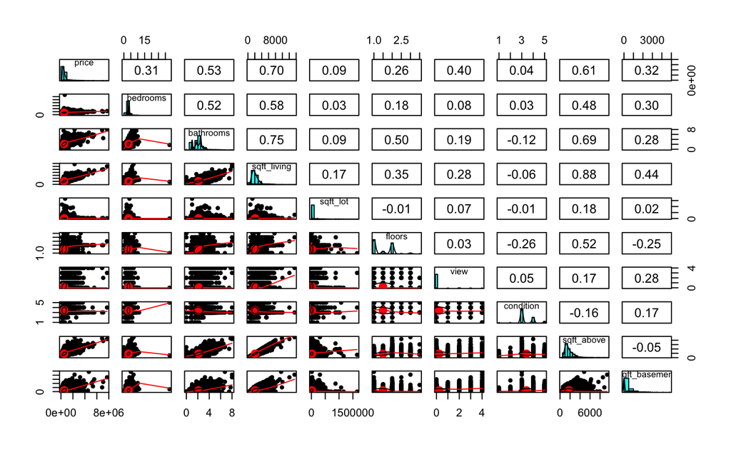

```r
pairs.panels(kc_house_data[c("price", "bedrooms", "bathrooms", "sqft_living", "sqft_lot", "floors", "view", "condition", "sqft_above", "sqft_basement")])
```

```r
mod1a <- lm(price ~ sqft_living, data = kc_house_data)
summary(mod1a)
```

```
Call:
lm(formula = price ~ sqft_living, data = kc_house_data)

Residuals:
     Min       1Q   Median       3Q      Max
-1476062  -147486   -24043   106182  4362067

Coefficients:
              Estimate Std. Error t value Pr(>|t|)
(Intercept) -43580.743   4402.690  -9.899   <2e-16 ***
sqft_living    280.624      1.936 144.920   <2e-16 ***
---
Signif. codes:  0 ‘***’ 0.001 ‘**’ 0.01 ‘*’ 0.05 ‘.’ 0.1 ‘ ’ 1

Residual standard error: 261500 on 21611 degrees of freedom
Multiple R-squared:  0.4929,    Adjusted R-squared:  0.4928
F-statistic: 2.1e+04 on 1 and 21611 DF,  p-value: < 2.2e-16
```

```r
mod1b <- lm(price ~ sqft_above, data = kc_house_data)
summary(mod1b)
```

```
Call:
lm(formula = price ~ sqft_above, data = kc_house_data)

Residuals:
    Min      1Q  Median      3Q     Max
-913132 -165624  -41468  109327 5339232

Coefficients:
            Estimate Std. Error t value Pr(>|t|)
(Intercept)  59953.2     4729.8   12.68   <2e-16 ***
sqft_above     268.5        2.4  111.87   <2e-16 ***
---
Signif. codes:  0 ‘***’ 0.001 ‘**’ 0.01 ‘*’ 0.05 ‘.’ 0.1 ‘ ’ 1

Residual standard error: 292200 on 21611 degrees of freedom
Multiple R-squared:  0.3667,    Adjusted R-squared:  0.3667
F-statistic: 1.251e+04 on 1 and 21611 DF,  p-value: < 2.2e-16
```

1a better (sqft_living) r sqrd 0.4929

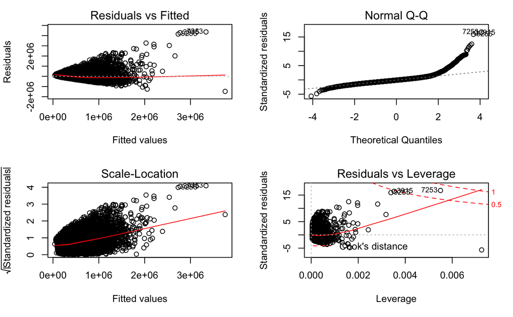

```r
par(mfrow = c(2,2))
plot(mod1a)
```

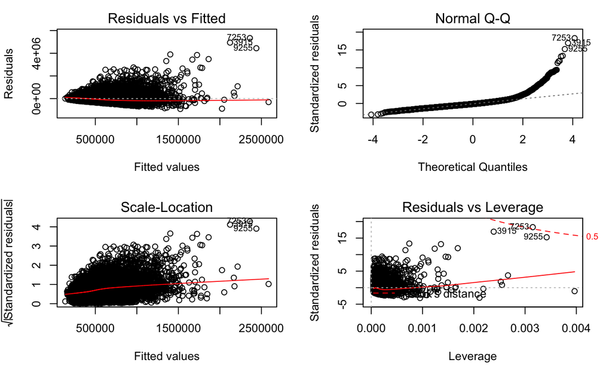

```r
plot(mod1b)
```

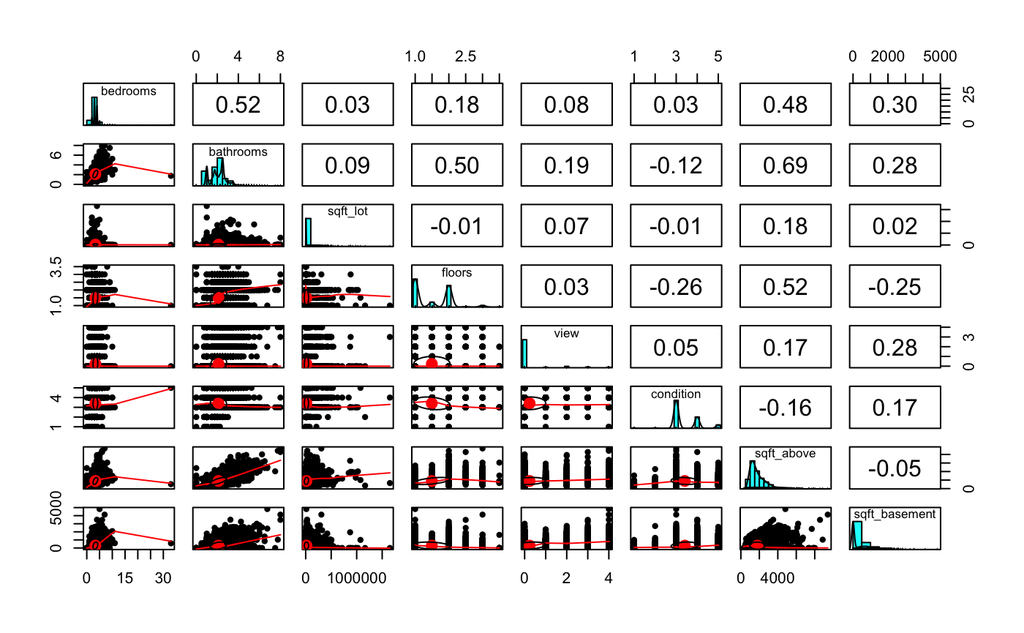

```r
kc_house_data_remaining_resid <- kc_house_data %>%
  add_residuals(mod1a) %>%
  select(-c("price", "sqft_living"))


pairs.panels(kc_house_data_remaining_resid[c("bedrooms", "bathrooms", "sqft_lot", "floors", "view", "condition", "sqft_above", "sqft_basement")])
```

Try bathrooms and the sqft_above

```r
mod2a <- lm(price ~ sqft_living + bathrooms, data = kc_house_data)
summary(mod2a)
```

```
Call:
lm(formula = price ~ sqft_living + bathrooms, data = kc_house_data)

Residuals:
     Min       1Q   Median       3Q      Max
-1483123  -147387   -24190   105951  4359876

Coefficients:
              Estimate Std. Error t value Pr(>|t|)
(Intercept) -39456.614   5223.129  -7.554 4.38e-14 ***
sqft_living    283.892      2.951  96.194  < 2e-16 ***
bathrooms    -5164.600   3519.452  -1.467    0.142
---
Signif. codes:  0 ‘***’ 0.001 ‘**’ 0.01 ‘*’ 0.05 ‘.’ 0.1 ‘ ’ 1

Residual standard error: 261400 on 21610 degrees of freedom
Multiple R-squared:  0.4929,    Adjusted R-squared:  0.4929
F-statistic: 1.05e+04 on 2 and 21610 DF,  p-value: < 2.2e-16
```

```r
mod2b <- lm(price ~ sqft_living + sqft_above, data = kc_house_data)
summary(mod2b)
```

```
Call:
lm(formula = price ~ sqft_living + sqft_above, data = kc_house_data)

Residuals:
     Min       1Q   Median       3Q      Max
-1503099  -147298   -23817   105296  4341387

Coefficients:
              Estimate Std. Error t value Pr(>|t|)
(Intercept) -40859.961   4447.950  -9.186  < 2e-16 ***
sqft_living    295.504      4.022  73.466  < 2e-16 ***
sqft_above     -18.827      4.461  -4.220 2.45e-05 ***
---
Signif. codes:  0 ‘***’ 0.001 ‘**’ 0.01 ‘*’ 0.05 ‘.’ 0.1 ‘ ’ 1

Residual standard error: 261400 on 21610 degrees of freedom
Multiple R-squared:  0.4933,    Adjusted R-squared:  0.4932
F-statistic: 1.052e+04 on 2 and 21610 DF,  p-value: < 2.2e-16
```

not much in it mod2b best r sqrd 0.4933

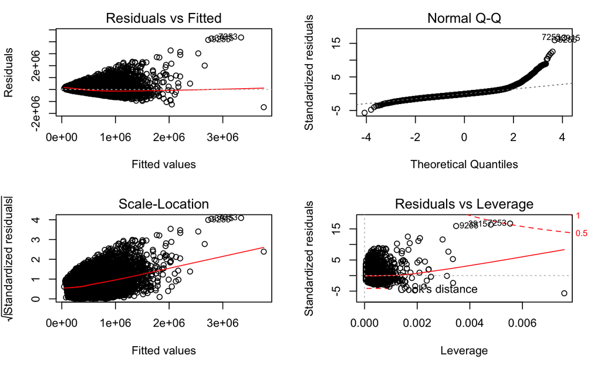

```r
par(mfrow = c(2,2))
plot(mod2a)
```

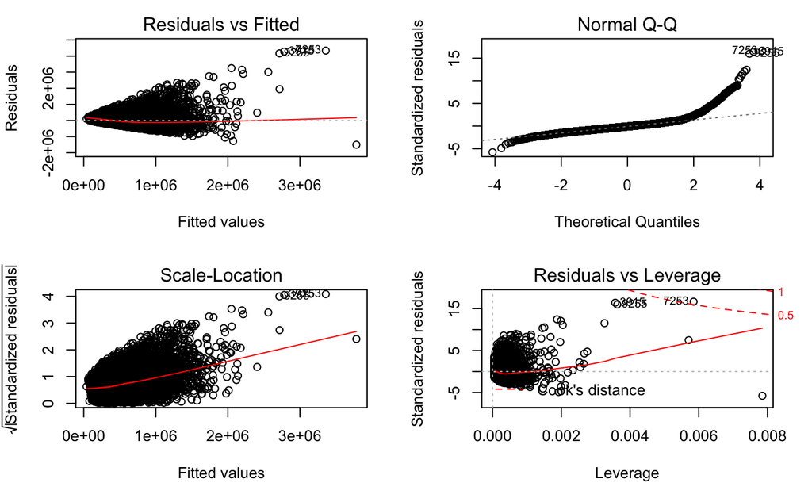

```r
plot(mod2b)
```

mod2b better (marginally) in both items are appearing in Cooks distance so some outliers having a disproportionate effect.

```r
anova(mod2a, mod2b)
```

```
Analysis of Variance Table

Model 1: price ~ sqft_living + bathrooms
Model 2: price ~ sqft_living + sqft_above
  Res.Df        RSS Df  Sum of Sq F Pr(>F)
1  21610 1.4771e+15
2  21610 1.4761e+15  0 1.0693e+12
```

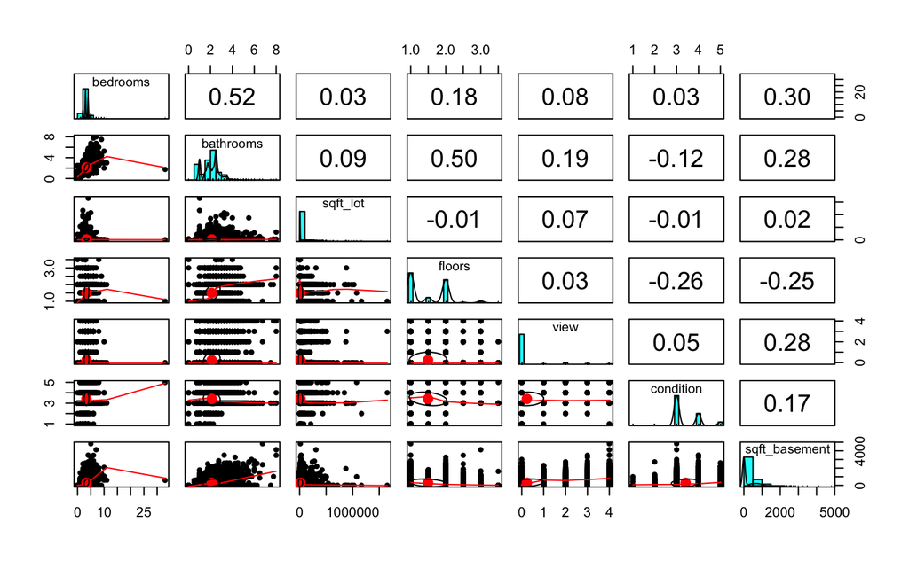

```r
kc_house_data_remaining_resid <- kc_house_data %>%
  add_residuals(mod2b) %>%
  select(-c("price", "sqft_living", "sqft_above"))


pairs.panels(kc_house_data_remaining_resid[c("bedrooms", "bathrooms", "sqft_lot", "floors", "view", "condition", "sqft_basement")])
```

```r
NA
NA
```

Bathrooms and sqft_basement next to try

```r
mod3a <- lm(price ~ sqft_living + sqft_above + bathrooms, data = kc_house_data)
summary(mod3a)
```

```
Call:
lm(formula = price ~ sqft_living + sqft_above + bathrooms, data = kc_house_data)

Residuals:
     Min       1Q   Median       3Q      Max
-1508101  -146907   -23843   105094  4340089

Coefficients:
              Estimate Std. Error t value Pr(>|t|)
(Intercept) -37667.487   5239.215  -7.190 6.71e-13 ***
sqft_living    297.771      4.477  66.510  < 2e-16 ***
sqft_above     -18.438      4.474  -4.121 3.78e-05 ***
bathrooms    -4068.289   3528.193  -1.153    0.249
---
Signif. codes:  0 ‘***’ 0.001 ‘**’ 0.01 ‘*’ 0.05 ‘.’ 0.1 ‘ ’ 1

Residual standard error: 261300 on 21609 degrees of freedom
Multiple R-squared:  0.4933,    Adjusted R-squared:  0.4932
F-statistic:  7013 on 3 and 21609 DF,  p-value: < 2.2e-16
```

```r
mod3b <- lm(price ~ sqft_living + sqft_above + sqft_basement, data = kc_house_data)
summary(mod3b)
```

```
Call:
lm(formula = price ~ sqft_living + sqft_above + sqft_basement,
    data = kc_house_data)

Residuals:
     Min       1Q   Median       3Q      Max
-1503099  -147298   -23817   105296  4341387

Coefficients: (1 not defined because of singularities)
                Estimate Std. Error t value Pr(>|t|)
(Intercept)   -40859.961   4447.950  -9.186  < 2e-16 ***
sqft_living      295.504      4.022  73.466  < 2e-16 ***
sqft_above       -18.827      4.461  -4.220 2.45e-05 ***
sqft_basement         NA         NA      NA       NA
---
Signif. codes:  0 ‘***’ 0.001 ‘**’ 0.01 ‘*’ 0.05 ‘.’ 0.1 ‘ ’ 1

Residual standard error: 261400 on 21610 degrees of freedom
Multiple R-squared:  0.4933,    Adjusted R-squared:  0.4932
F-statistic: 1.052e+04 on 2 and 21610 DF,  p-value: < 2.2e-16
```

no difference in R squrd figure of 0.4933 for both.

```r
anova(mod3a, mod3b)
```

```
Analysis of Variance Table

Model 1: price ~ sqft_living + sqft_above + bathrooms
Model 2: price ~ sqft_living + sqft_above + sqft_basement
  Res.Df        RSS Df   Sum of Sq      F Pr(>F)
1  21609 1.4760e+15
2  21610 1.4761e+15 -1 -9.0816e+10 1.3296 0.2489
```

```
* splitting datasets into numeric and non-numeric columns might help `ggpairs()` run in manageable time, although you will need to add either a `price` or `resid` column to the non-numeric dataframe in order to see its correlations with the non-numeric predictors.
```

**Hints**

```r
houses_tidy_numeric <- houses_tidy %>%
  select_if(is.numeric)

houses_tidy_nonnumeric <- houses_tidy %>%
  select_if(function(x) !is.numeric(x))

houses_tidy_nonnumeric$price <- houses_tidy$price

ggpairs(houses_tidy_numeric)
ggpairs(houses_tidy_nonnumeric)
```

and the same in subsequent rounds of predictor selection with the `resid` column.  
Remember, if you are not sure whether including a categorical predictor is statistically justified, run an `anova()` test passing in the models with- and without the categorical predictor and check the p-value of the test.

# Extensions

- Consider possible interactions between your four main effect predictors and test their effect upon $r^2$. Choose your best candidate interaction and visualise its effect.
- Calculate the relative importance of predictors from your best $4$-predictor model (i.e. the model without an interaction). Which predictor affects `price` most strongly?